# Recommendations for Campaign Managers

Aswin.P

24 November 2017

## Introduction

This HTML document provides the recommendations and supporting visuals and tables for optimizing the Campaign spend across different dimensions. The codes (including the Data prep) are in the R markdown file. For Information regarding the steps followed for Data preparation, check the Appendix section at the end.

### Recommendation 1:

1. Only **~21%** of the Total Media spend is responsible for the entire sales/conversions. Around **$4625(~79% of the Total spends)** can be repurposed to target the existing Conversion areas, thereby optimising our spends

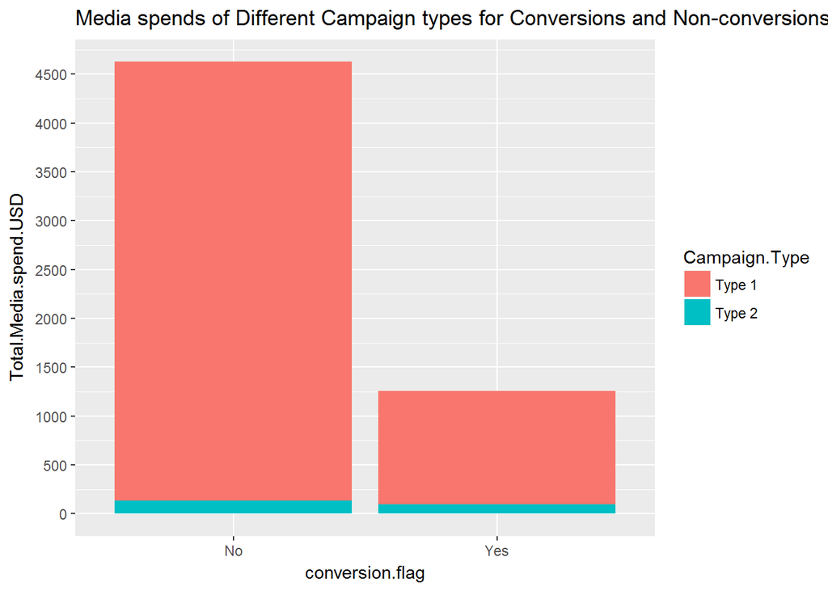

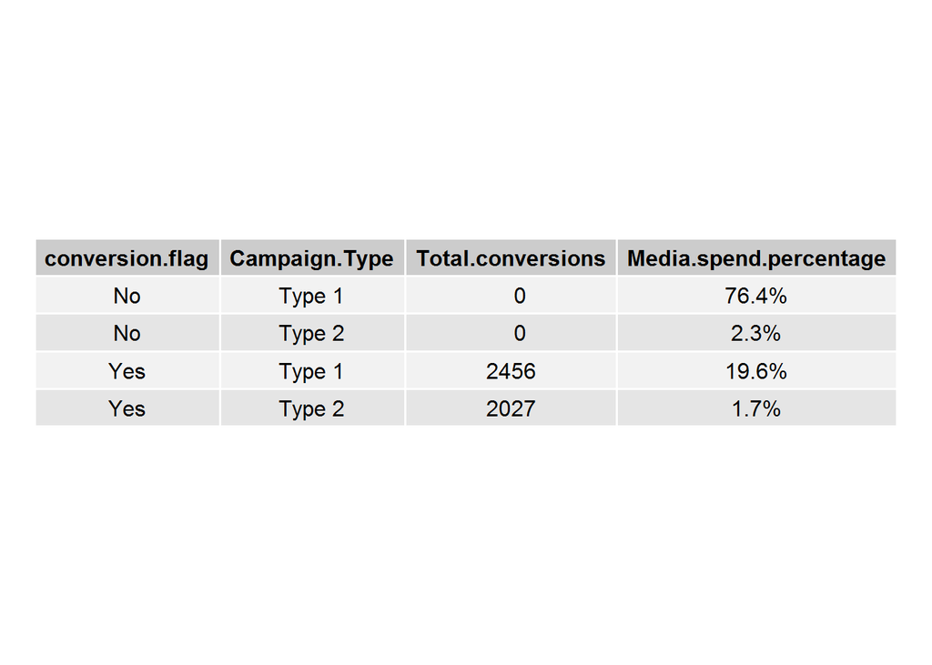

### Recommendation 2:

From the above table, we can find that **Type 1 Campaign** is bringing nearly the same amount of sales as **Type 2 Campaign**. But the Total spend of Type 1 is **24 times**(around 96% of entire spend) greater than the spend for Type 2 campaign, as shown by the below pie graph. Repurposing the amount from Non- performing Dimesions of Type 1 to Type 2 can help in optimising the spend while maintaining the sales at low CPC(cost per conversion), since evident from the below bar graph, Type 2 has very low CPC compared to Type 1 conversions. *Note- CPC being calculated for each record and summed up*

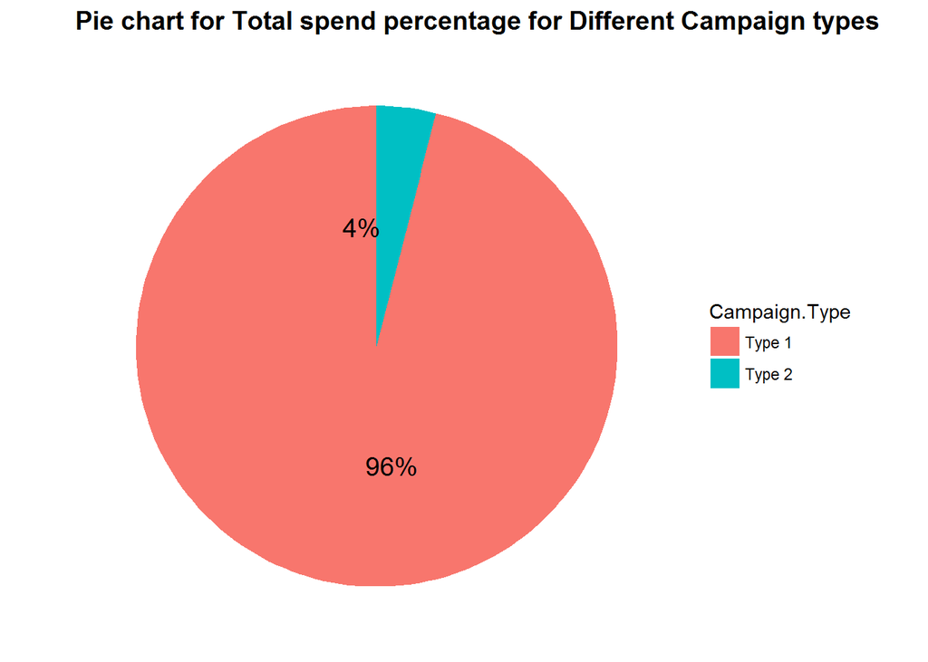

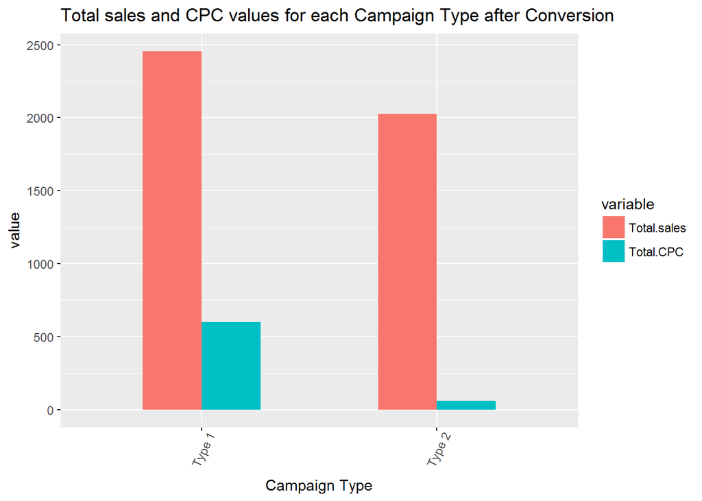

### Recommendation 3:

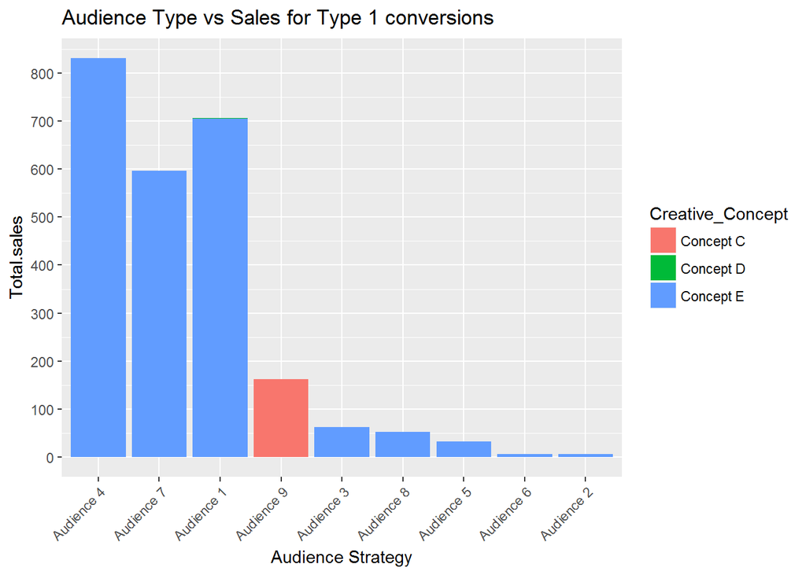

```
## [1] "Data for Type 1 conversions"
```

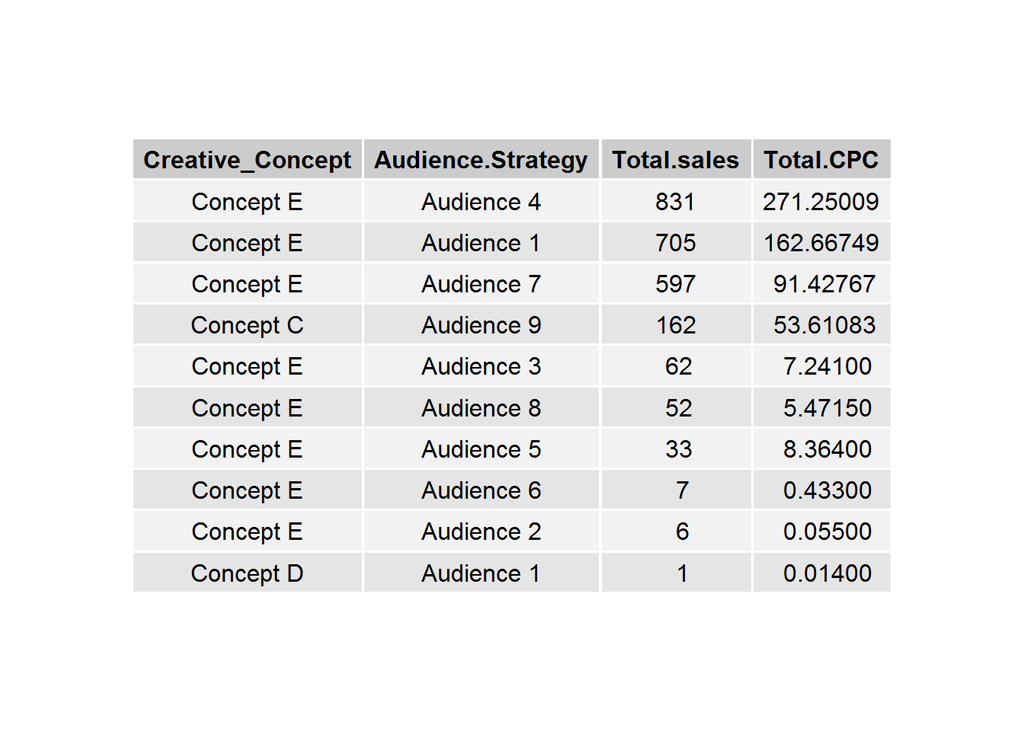

```
## [1] "Data for Type 2 conversions"
```

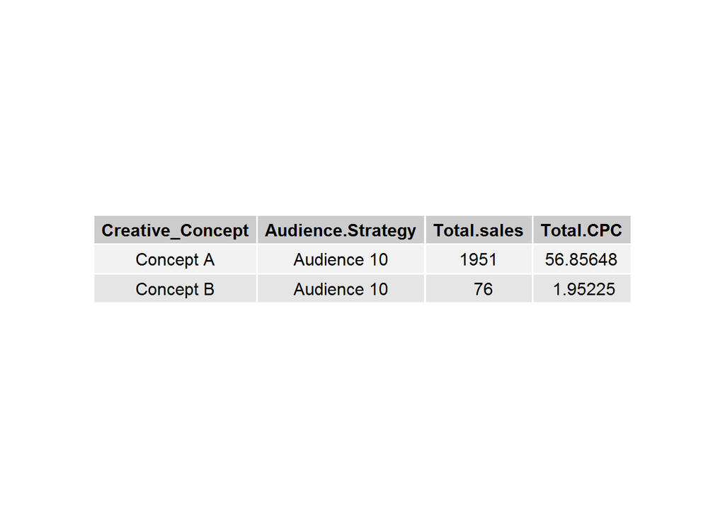

### Recommendation 4:

Among 9 distinct creative sizes, for both Type 1, 2 Campaigns, *increase* the Campaigns for the Sizes **300X250, 728X90, 160X600, 300X600**, since they capture **~ 60%** of the Total sales.

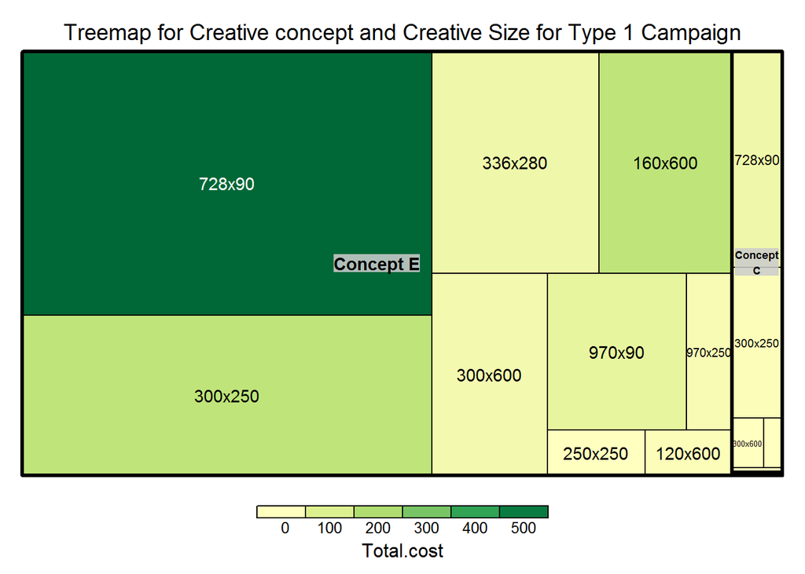

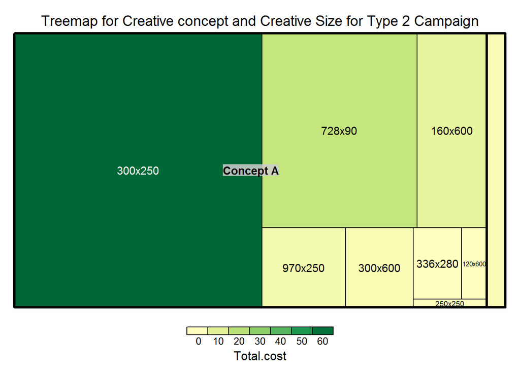

### Recommendation 5:

**99 cities** are present in Type 1 campaign and **70** in Type 2 campaign. Irrespective of the Type of Campaign, it is recommended to concentrate on the **top 10 Cities(Cities 17,5,28,36,16,3,11,7,34,57)** in both the scenarios as they account for **~70-75%** of the Total sales. Also from the below graph, the top cities sales counts are the same, but Total spends in Cities with Type 2 campaign are less than the same cities with type 1 campaign.

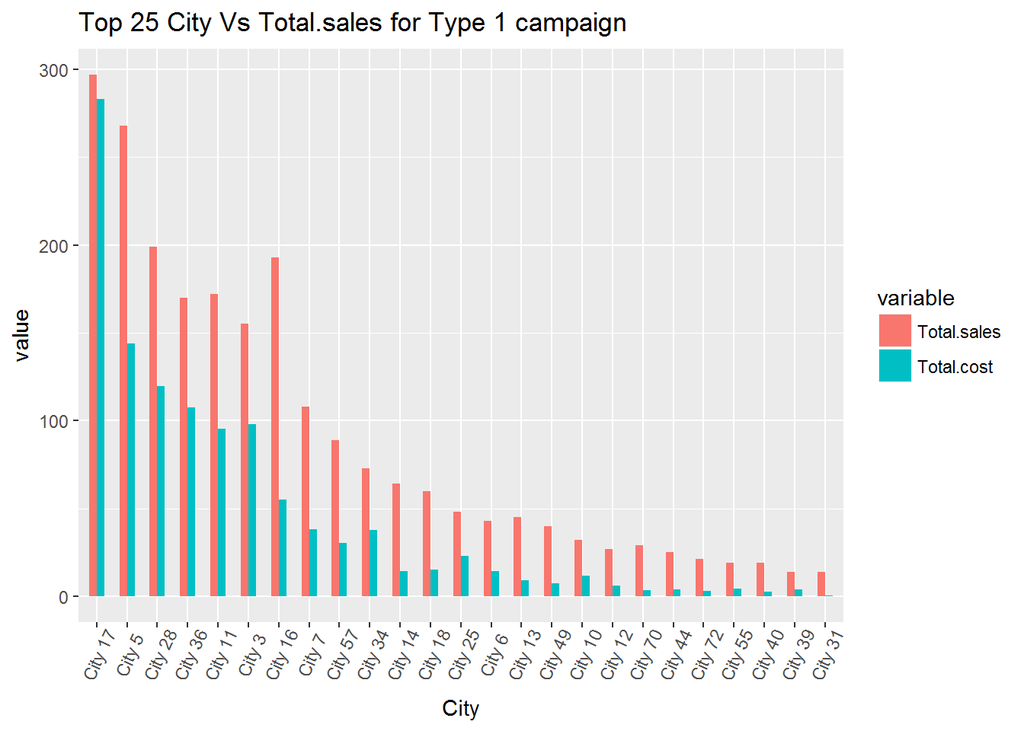

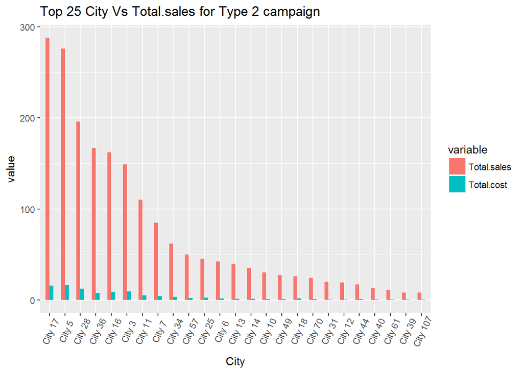

### Recommendation 6:

Conversions happen on total of **945** sites at a spend of **$1235**, but an additional **$4625(4 times greater than the spend for conversion sites)** is spent on a whopping **13017** sites where sales doesn’t occur. This is where most of the money is wasted and it is recommended that such sites should not be engaged with in future.

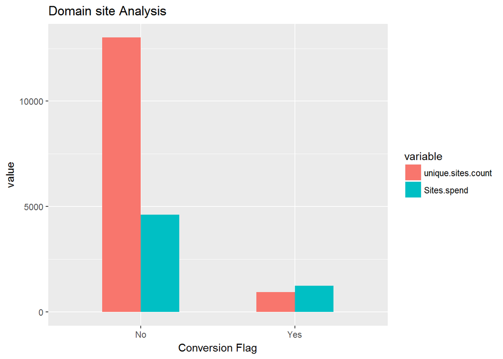

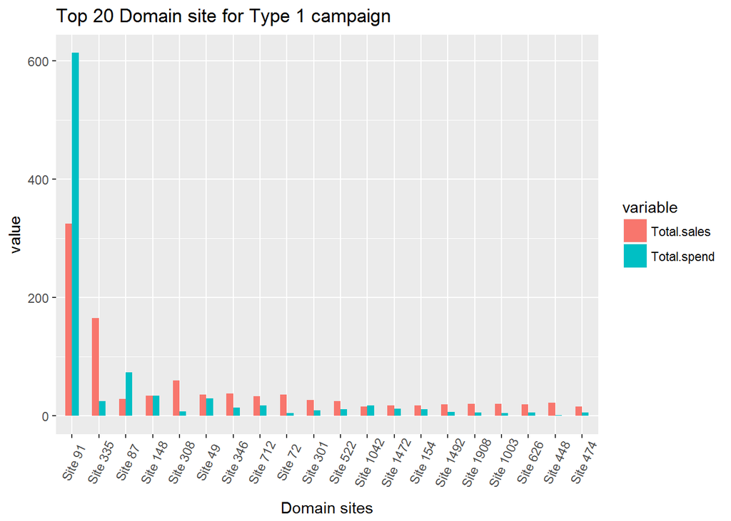

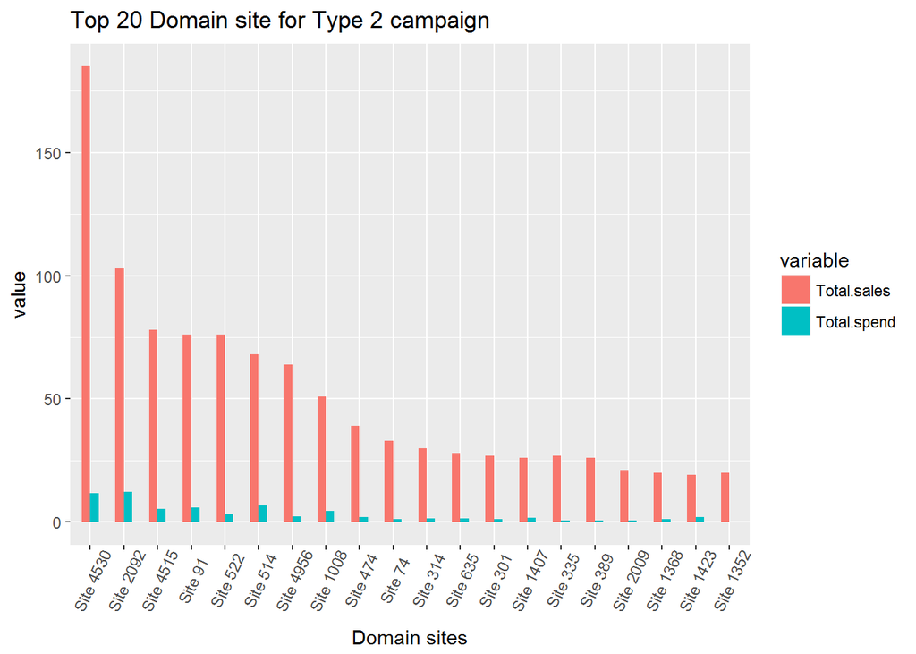

### Recommendation 7:

Combining all of the above recommended high impact areas together, we get a finite combination of Areas to concentrate. These categories account for around **2478 or ~55%** of the total sales, with a Total CPC of **$383** and a total spend of **$845**, which is **~14%** of the whole Media spend.

```
## [1] "Sales made by the Recommended Dimensions( in units)"
```

```
## [1] 2478
```

```
## [1] "Percentage of Recommended sales from the total sales"
```

```
## [1] "55.3%"
```

```
## [1] "Total spend of Recommended Dimensions(in $)"
```

```
## [1] 845.32
```

```
## [1] "Percentage of Recommended spend from the total spend"
```

```
## [1] "14.4%"
```

```
## [1] "Total CPC of Recommended Dimesions(in $)"
```

```
## [1] 383.5677
```

```
## [1] "Percentage of Recommended CPC from the Total CPC in the campaigns"
```

```
## [1] "58.2%"
```

### Correlogram of Metrics:

As expected from the business, all the continous Metrics are correlated with varying levels of positivity

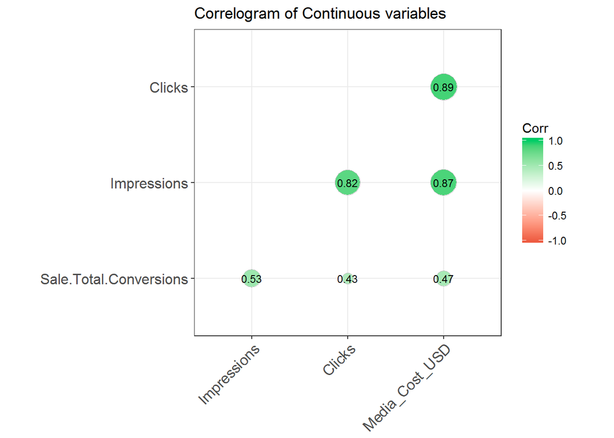

## Appendix

- The Data received is clean without missing values.
- No.of.rows = 207770
- No.of.columns = 11
- No.of.Duplicate Entries across 7 dimesions= 7080
- My assumption= Duplicate entries exist either because the entry was made twice or the data was subsetted from a time period(say data for month 1 full and 1 or 2 days data of month 2). I went with the second scenario.
- My solution= Summed up the entries for the given time period.
- Records after Deduplication = 200690